# Lake Frances Project Correlations

Cheyenne Morgan

2026-03-05

### Lake Frances Correlation Matrix Development - March 2026(update)

## The Correlation Matrix Method

# Intro

This document includes the information and coding that was used to create the correlation matrices for Lake Frances soils analytical data. The data includes all collected information for sample location LF 3 - LF 46. To date all parameters were analyzed for locations LF 3 - LF 43. No P or metals data have been collected for locations LF 44-46 at the time of this update (03/04/2026).

#Working Directory and Setup Getting the working directory

```r
getwd()
```

```
## [1] "C:/Users/Green/Documents/Modeling/R/RESEARCH/LF_Working/LF Basics"
```

Reading the data into R

```r
lfran<-read.csv("LF_Master_03042026.csv")
head(lfran)
```

```
##   UID DEPTH    DEPTH_A AREA   ELEV    SAND_P   CLAY_P   SILT_P  pH  SMC LOI WEP
## 1  3a    10  0-10cmbgs    1 280.10 27.378975 13.93485 58.68618 6.7 34.6 3.7 2.7
## 2  3b    20 10-20cmbgs    1 280.10  5.107925 17.64275 77.24933  NA 28.8 2.3 1.8
## 3  4a    10  0-10cmbgs    1 280.36  9.996882 12.67228 77.33084  NA 39.5 3.0 4.6
## 4  4b    20 10-20cmbgs    1 280.36 17.407783 13.93182 68.66040 6.6 32.6 2.3 5.7
## 5  5a    10  0-10cmbgs    1 280.93 18.634823 12.68677 68.67840 6.9 31.2 3.5 3.3
## 6  5b    20 10-20cmbgs    1 280.93        NA       NA       NA  NA 27.3 2.7 4.5
##   WEP100  MM3   M3    TP  AG     AL  AS    BA     CA  CD  CO   CR   CU      FE
## 1   40.9  4.8  7.2 268.2 0.2 7875.7 5.6 128.1 4878.1 2.5 9.6 17.2 12.4 13114.5
## 2     NA   NA  8.8 304.0  NA 5610.8 4.8 125.0 3049.7  NA 8.4 14.9 11.3 15066.3
## 3     NA  7.7 12.7 337.2 0.2 7497.3 4.4 114.2 4124.9 2.3 9.3 15.1 11.7 13013.8
## 4     NA 12.7 20.6 375.4 0.2 6070.3 5.3 121.5 3492.5 2.7 9.7 15.0 11.4 14708.3
## 5   34.3  4.6  9.5 266.3 0.2 6200.9 4.7 115.3 4787.0 2.4 9.0 15.0 11.0 13453.6
## 6     NA  6.4 10.5 370.4 0.2 8361.7 4.9 120.6 4251.4 2.6 9.6 18.4 11.6 13113.2
##       K   LI    MG     MN  NA.   NI   PB     S SE   SI   ZN P_sorb   PSI
## 1 924.0 13.4 663.8  974.5 35.0 18.2 16.1 318.6 NA 28.7 60.5  380.0 217.4
## 2 720.5  8.0 515.7  967.7 26.8 12.8 38.0 264.9 NA 26.2 50.0  396.8 227.8
## 3 896.4 10.5 597.0  923.6 25.3 16.6 15.0 260.8 NA 31.0 53.9  374.8 214.1
## 4 899.2  9.3 574.2 1058.6 23.3 15.8 26.5 225.7 NA 26.3 61.1  393.2 225.6
## 5 857.9 10.1 587.1  946.2 25.1 15.0 24.3 323.5 NA 33.4 54.9  349.6 198.7
## 6 991.8 14.7 679.6  957.3 32.4 18.0 15.8 262.9 NA 34.8 59.9  349.6 198.7
```

Variables in the data frame

```r
names(lfran)
```

```
##  [1] "UID"     "DEPTH"   "DEPTH_A" "AREA"    "ELEV"    "SAND_P"  "CLAY_P"
##  [8] "SILT_P"  "pH"      "SMC"     "LOI"     "WEP"     "WEP100"  "MM3"
## [15] "M3"      "TP"      "AG"      "AL"      "AS"      "BA"      "CA"
## [22] "CD"      "CO"      "CR"      "CU"      "FE"      "K"       "LI"
## [29] "MG"      "MN"      "NA."     "NI"      "PB"      "S"       "SE"
## [36] "SI"      "ZN"      "P_sorb"  "PSI"
```

# Soil Depth Interval: 0-10 cm bgs

Only looking at correlations between data from 0-10cmbgs

```r
lfran10<-read.csv("LF_Soil_10_data_030426.csv")
names(lfran10)
```

```
##  [1] "Samp_ID"   "Samp_Loc"  "Latitude"  "Longitude" "UID"       "Depth"
##  [7] "Unit"      "Area"      "Elev"      "Soil_Type" "SandPD"    "ClayPD"
## [13] "SiltPD"    "pH_soil"   "SMC"       "LOI"       "WEP_2024"  "WEP_2025"
## [19] "WEP100"    "MM3P"      "M3P"       "TP"        "Ag_tot"    "Al_tot"
## [25] "As_tot"    "Ba_tot"    "Ca_tot"    "Cd_tot"    "Co_tot"    "Cr_tot"
## [31] "Cu_tot"    "Fe_tot"    "K_tot"     "Li_tot"    "Mg_tot"    "Mn_tot"
## [37] "Na_tot"    "Ni_tot"    "Pb_tot"    "S_tot"     "Se_tot"    "Si_tot"
## [43] "Zn_tot"    "P_sorb"    "PSI"
```

Creating the subsets

```r
library(dplyr)
mydat10<-select(lfran10,Elev, SandPD, ClayPD, SiltPD, SMC, LOI, WEP_2024, WEP_2025, M3P, TP, Al_tot, As_tot, Fe_tot, Ca_tot, Mg_tot, Na_tot, Si_tot, P_sorb, PSI)
```

Finding potential potential statistical correlations using a “snapshot” method.

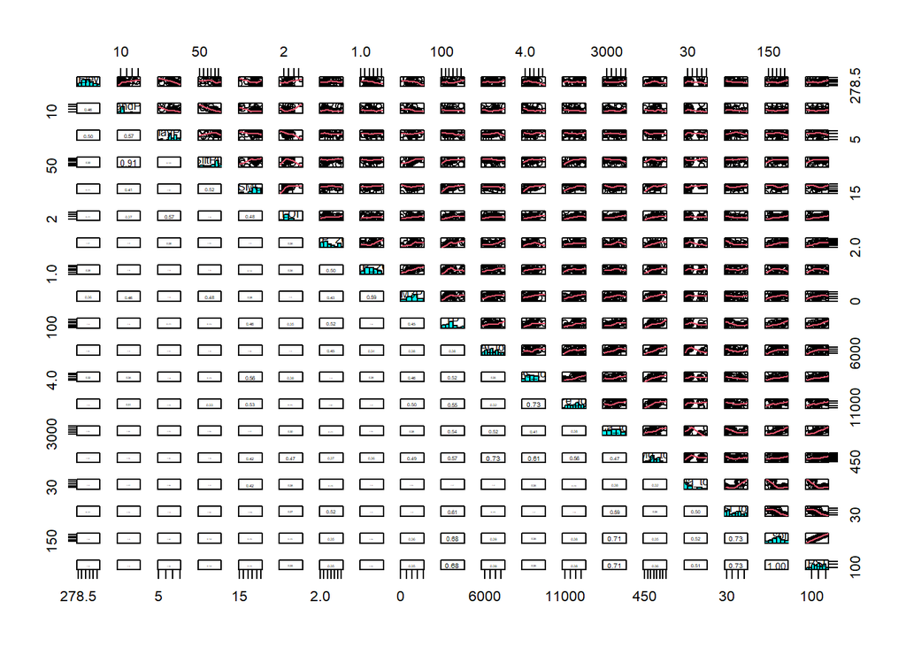

```r
library(s20x)
pairs20x(mydat10)
```

```r
cor(mydat10,y=NULL, use = "na.or.complete", method = c("spearman"))
```

```
##                  Elev       SandPD        ClayPD       SiltPD          SMC
## Elev      1.000000000  0.454343263 -0.5015478705 -0.264600667  0.011844556
## SandPD    0.454343263  1.000000000 -0.4365105562 -0.828889116 -0.298667981
## ClayPD   -0.501547871 -0.436510556  1.0000000000 -0.022013424 -0.178695930
## SiltPD   -0.264600667 -0.828889116 -0.0220134238  1.000000000  0.483481395
## SMC       0.011844556 -0.298667981 -0.1786959298  0.483481395  1.000000000
## LOI       0.156285176  0.241332942 -0.4843711834 -0.088221126  0.453019931
## WEP_2024  0.068577784  0.007907092 -0.2889855823  0.027530872  0.049839680
## WEP_2025 -0.309650317 -0.019891277 -0.0386139193  0.004074075  0.092030695
## M3P      -0.361303456 -0.470944296  0.1240890857  0.454074800  0.252679563
## TP        0.076742850 -0.115963611 -0.2853450221  0.167159809  0.421286031
## Al_tot    0.063163183  0.073763509  0.1485242419 -0.264267324 -0.035718685
## As_tot   -0.255474611 -0.191365807  0.1228005107  0.163288329  0.455164724
## Fe_tot   -0.035035828 -0.153447835  0.0007413856  0.219154525  0.474442669
## Ca_tot    0.059462216  0.126804160 -0.1112078350 -0.194995759  0.051484173
## Mg_tot    0.043177957 -0.040952316 -0.0328680935 -0.005669915  0.361867228
## Na_tot    0.008143132 -0.065877200  0.0451065106  0.122534550  0.457748214
## Si_tot   -0.218850561 -0.002960408  0.1527254267  0.049550123 -0.007882744
## P_sorb    0.227979615 -0.073023407 -0.1668117525  0.010846793  0.044094101
## PSI       0.227979615 -0.073023407 -0.1668117525  0.010846793  0.044094101
##                  LOI     WEP_2024     WEP_2025        M3P          TP
## Elev      0.15628518  0.068577784 -0.309650317 -0.3613035  0.07674285
## SandPD    0.24133294  0.007907092 -0.019891277 -0.4709443 -0.11596361
## ClayPD   -0.48437118 -0.288985582 -0.038613919  0.1240891 -0.28534502
## SiltPD   -0.08822113  0.027530872  0.004074075  0.4540748  0.16715981
## SMC       0.45301993  0.049839680  0.092030695  0.2526796  0.42128603
## LOI       1.00000000  0.399827640  0.256067996  0.2496616  0.59236313
## WEP_2024  0.39982764  1.000000000  0.565480603  0.5368296  0.53034847
## WEP_2025  0.25606800  0.565480603  1.000000000  0.5653306  0.24549743
## M3P       0.24966155  0.536829612  0.565330564  1.0000000  0.45213749
## TP        0.59236313  0.530348472  0.245497432  0.4521375  1.00000000
## Al_tot    0.21486126  0.426298809  0.371037852  0.3503326  0.29264688
## As_tot    0.53384603  0.212518718  0.254329734  0.4379261  0.61660307
## Fe_tot    0.43318404  0.100160484  0.092512762  0.4794284  0.55622614
## Ca_tot    0.56571067  0.232145358  0.051313746  0.2384824  0.59662520
## Mg_tot    0.53233176  0.396941426  0.336746455  0.4503572  0.46212588
## Na_tot    0.19164326 -0.111152355  0.138662871  0.1342861 -0.03781720
## Si_tot   -0.48659030 -0.442827756 -0.005180715 -0.1544715 -0.61042001
## P_sorb    0.42181049  0.359442919 -0.065128985  0.2820892  0.65870182
## PSI       0.42181049  0.359442919 -0.065128985  0.2820892  0.65870182
```

[output cut: 25 more lines]

```
## SMC       0.457748214 -0.007882744  0.04409410  0.04409410
## LOI       0.191643257 -0.486590296  0.42181049  0.42181049
## WEP_2024 -0.111152355 -0.442827756  0.35944292  0.35944292
## WEP_2025  0.138662871 -0.005180715 -0.06512898 -0.06512898
## M3P       0.134286067 -0.154471549  0.28208919  0.28208919
## TP       -0.037817196 -0.610420007  0.65870182  0.65870182
## Al_tot    0.178593424 -0.288669951  0.39310345  0.39310345
## As_tot    0.246542412 -0.316167757  0.30900458  0.30900458
## Fe_tot    0.334031287 -0.166009852  0.36650246  0.36650246
## Ca_tot   -0.159871907 -0.616256158  0.70492611  0.70492611
## Mg_tot    0.599334898 -0.311822660  0.31231527  0.31231527
## Na_tot    1.000000000  0.235989656 -0.31703412 -0.31703412
## Si_tot    0.235989656  1.000000000 -0.76945813 -0.76945813
## P_sorb   -0.317034120 -0.769458128  1.00000000  1.00000000
## PSI      -0.317034120 -0.769458128  1.00000000  1.00000000
```

# Soil Depth Interval: 10-20 cmbgs

Only looking at correlations between data from 10-20cmbgs

```r
lfran20<-read.csv("LF_Soil_20_data_030426.csv")
names(lfran20)
```

```
##  [1] "Samp_ID"   "Samp_Loc"  "Latitude"  "Longitude" "UID"       "Depth"
##  [7] "Unit"      "Area"      "Elev"      "Soil_Type" "SandPD"    "ClayPD"
## [13] "SiltPD"    "pH_soil"   "SMC"       "LOI"       "WEP_2024"  "WEP_2025"
## [19] "WEP100"    "MM3P"      "M3P"       "TP"        "Ag_tot"    "Al_tot"
## [25] "As_tot"    "Ba_tot"    "Ca_tot"    "Cd_tot"    "Co_tot"    "Cr_tot"
## [31] "Cu_tot"    "Fe_tot"    "K_tot"     "Li_tot"    "Mg_tot"    "Mn_tot"
## [37] "Na_tot"    "Ni_tot"    "Pb_tot"    "S_tot"     "Se_tot"    "Si_tot"
## [43] "Zn_tot"    "P_sorb"    "PSI"
```

```r
mydat20<-select(lfran20,Elev, SandPD, ClayPD, SiltPD, SMC, LOI, WEP_2024, WEP_2025, M3P, TP, Al_tot, As_tot, Fe_tot, Ca_tot, Mg_tot, Na_tot, Si_tot, P_sorb, PSI)
```

Correlation Snapshot: 10-20 cmbgs

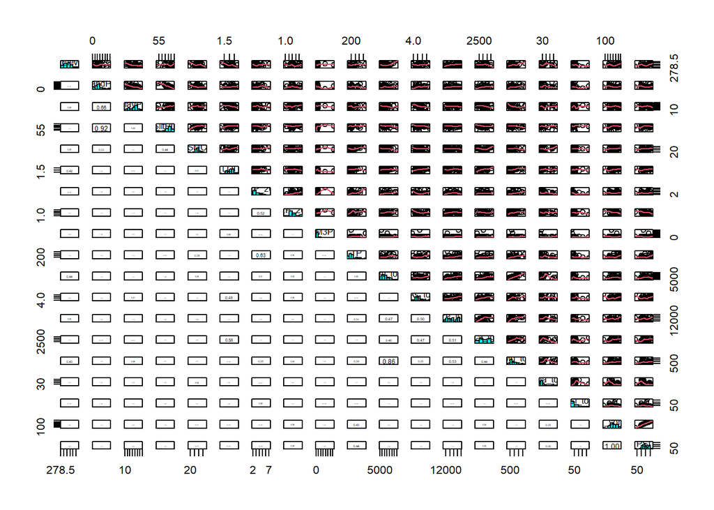

```r
library(s20x)
pairs20x(mydat20)
```

```r
cor(mydat20,y=NULL, use = "na.or.complete", method = c("spearman"))
```

```
##                   Elev       SandPD       ClayPD      SiltPD         SMC
## Elev      1.0000000000  0.230545441 -0.318940477 -0.16819994 -0.04285612
## SandPD    0.2305454405  1.000000000 -0.613958671 -0.84666090 -0.30843348
## ClayPD   -0.3189404767 -0.613958671  1.000000000  0.17710378 -0.13269012
## SiltPD   -0.1681999387 -0.846660897  0.177103782  1.00000000  0.37499101
## SMC      -0.0428561160 -0.308433476 -0.132690118  0.37499101  1.00000000
## LOI      -0.2741889312  0.036173148 -0.296358059  0.11864680  0.35195233
## WEP_2024  0.0869433346  0.054977841 -0.005676196 -0.08457076  0.08281763
## WEP_2025 -0.0437878439 -0.106003839  0.193495251  0.05978725  0.03912579
## M3P       0.0764580909 -0.032038547  0.024085480  0.07354978 -0.07380243
## TP        0.1933116946 -0.057649688 -0.169966070  0.18489353  0.25500382
## Al_tot    0.2505552209  0.219129980 -0.129928936 -0.18902608 -0.15171887
## As_tot    0.0005359062  0.224644356 -0.326481061 -0.08153430  0.06495988
## Fe_tot    0.3195841792  0.119428133 -0.103544312 -0.03994802 -0.09977082
## Ca_tot   -0.1457107943  0.303387216 -0.267221024 -0.17525090  0.03682200
## Mg_tot    0.3146863373  0.199250778 -0.293912447 -0.06902896  0.14805195
## Na_tot    0.0749982030  0.053215096 -0.109373473  0.05984550  0.16974790
## Si_tot   -0.2182600764  0.004587508  0.056297426  0.06918202 -0.02765470
## P_sorb    0.0607684927 -0.140770801 -0.061824512  0.15544182  0.20933608
## PSI       0.0607684927 -0.140770801 -0.061824512  0.15544182  0.20933608
##                   LOI     WEP_2024     WEP_2025         M3P          TP
## Elev     -0.274188931  0.086943335 -0.043787844  0.07645809  0.19331169
## SandPD    0.036173148  0.054977841 -0.106003839 -0.03203855 -0.05764969
## ClayPD   -0.296358059 -0.005676196  0.193495251  0.02408548 -0.16996607
## SiltPD    0.118646802 -0.084570761  0.059787248  0.07354978  0.18489353
## SMC       0.351952328  0.082817633  0.039125785 -0.07380243  0.25500382
## LOI       1.000000000 -0.008864435 -0.083390660 -0.15902491  0.29617178
## WEP_2024 -0.008864435  1.000000000  0.615819657  0.27246333  0.49629460
## WEP_2025 -0.083390660  0.615819657  1.000000000  0.38005351  0.43985941
## M3P      -0.159024914  0.272463325  0.380053506  1.00000000  0.48132019
## TP        0.296171781  0.496294600  0.439859412  0.48132019  1.00000000
## Al_tot    0.060212426  0.400947362  0.357022789  0.09137444  0.39770817
## As_tot    0.477985023 -0.146820551 -0.272609129  0.12717824  0.34650366
## Fe_tot    0.154504474  0.115669647  0.204799031  0.30055772  0.57188694
## Ca_tot    0.548330419  0.022308809 -0.143817827 -0.22385209  0.21130634
## Mg_tot    0.366317729  0.484987395  0.277242868  0.05836962  0.52146677
## Na_tot    0.034232445 -0.179692872 -0.120739727 -0.16227367 -0.16546982
## Si_tot   -0.082218998 -0.304377723  0.004890723 -0.10848804 -0.33200917
## P_sorb    0.291456522 -0.025366748 -0.274665655 -0.08710269  0.31965773
## PSI       0.291456522 -0.025366748 -0.274665655 -0.08710269  0.31965773
```

[output cut: 25 more lines]

```
## SMC       0.16974790 -0.027654698  0.20933608  0.20933608
## LOI       0.03423245 -0.082218998  0.29145652  0.29145652
## WEP_2024 -0.17969287 -0.304377723 -0.02536675 -0.02536675
## WEP_2025 -0.12073973  0.004890723 -0.27466565 -0.27466565
## M3P      -0.16227367 -0.108488044 -0.08710269 -0.08710269
## TP       -0.16546982 -0.332009167  0.31965773  0.31965773
## Al_tot    0.03009931 -0.032849503  0.09336084  0.09336084
## As_tot    0.05043944  0.026136800  0.22409050  0.22409050
## Fe_tot    0.02796028 -0.113827349  0.07181603  0.07181603
## Ca_tot    0.06340718 -0.027960275  0.31965773  0.31965773
## Mg_tot    0.20641711 -0.141329259  0.09916724  0.09916724
## Na_tot    1.00000000  0.467685256 -0.32546413 -0.32546413
## Si_tot    0.46768526  1.000000000 -0.42570097 -0.42570097
## P_sorb   -0.32546413 -0.425700972  1.00000000  1.00000000
## PSI      -0.32546413 -0.425700972  1.00000000  1.00000000
```

# Soil Depth Interval: 20-30 cmbgs

Only looking at correlations between data from 20-30 cmbgs

```r
lfran30<-read.csv("LF_Soil_30_data_030426.csv")
names(lfran30)
```

```
##  [1] "Samp_ID"   "Samp_Loc"  "Latitude"  "Longitude" "UID"       "Depth"
##  [7] "Unit"      "Area"      "Elev"      "Soil_Type" "SandPD"    "ClayPD"
## [13] "SiltPD"    "pH_soil"   "SMC"       "LOI"       "WEP_2024"  "WEP_2025"
## [19] "WEP100"    "MM3P"      "M3P"       "TP"        "Ag_tot"    "Al_tot"
## [25] "As_tot"    "Ba_tot"    "Ca_tot"    "Cd_tot"    "Co_tot"    "Cr_tot"
## [31] "Cu_tot"    "Fe_tot"    "K_tot"     "Li_tot"    "Mg_tot"    "Mn_tot"
## [37] "Na_tot"    "Ni_tot"    "Pb_tot"    "S_tot"     "Se_tot"    "Si_tot"
## [43] "Zn_tot"    "P_sorb"    "PSI"
```

```r
mydat30<-select(lfran30,Elev, SandPD, ClayPD, SiltPD, SMC, LOI, WEP_2024, WEP_2025, M3P, TP, Al_tot, As_tot, Fe_tot, Ca_tot, Mg_tot, Na_tot, Si_tot, P_sorb, PSI)
```

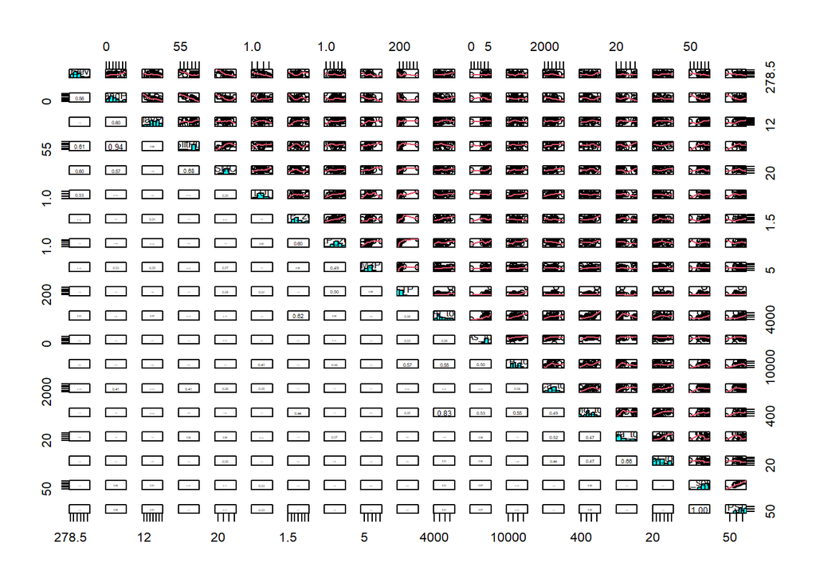

```r
library(s20x)
pairs20x(mydat30)
```

```r
cor(mydat30,y=NULL, use = "na.or.complete", method = c("spearman"))
```

```
##                  Elev       SandPD       ClayPD       SiltPD         SMC
## Elev      1.000000000  0.400463597 -0.202669370 -0.413296102 -0.43748836
## SandPD    0.400463597  1.000000000 -0.576655744 -0.924753502 -0.54608708
## ClayPD   -0.202669370 -0.576655744  1.000000000  0.308664141  0.05986912
## SiltPD   -0.413296102 -0.924753502  0.308664141  1.000000000  0.53638675
## SMC      -0.437488358 -0.546087077  0.059869122  0.536386746  1.00000000
## LOI      -0.609014590 -0.005398128 -0.027418646 -0.001160787  0.31467591
## WEP_2024  0.076508033  0.052855037  0.263332350 -0.110144862 -0.27983066
## WEP_2025 -0.113636499  0.048583149  0.140568833 -0.178374266  0.10194268
## M3P      -0.182588815 -0.102950005  0.256422266  0.014316373  0.21196384
## TP       -0.251155922 -0.149990832  0.008882097  0.169087970  0.34198885
## Al_tot    0.208782991 -0.032774346  0.283454734 -0.065004071 -0.02500481
## As_tot   -0.009632064 -0.279599669  0.111433817  0.225042491  0.39553674
## Fe_tot    0.111710456  0.057451501 -0.022012152 -0.112983266  0.13348721
## Ca_tot   -0.186826108 -0.291498891  0.130142024  0.321151065  0.48355454
## Mg_tot    0.083205029 -0.218238588  0.230934511  0.139294438  0.22196577
## Na_tot    0.079738153 -0.254868740  0.063333210  0.241443692  0.30121178
## Si_tot    0.166410059 -0.111432777  0.096930706  0.109113976  0.31659935
## P_sorb   -0.265844973  0.048206839  0.239476487 -0.056502500 -0.30415544
## PSI      -0.265844973  0.048206839  0.239476487 -0.056502500 -0.30415544
##                   LOI     WEP_2024    WEP_2025         M3P           TP
## Elev     -0.609014590  0.076508033 -0.11363650 -0.18258881 -0.251155922
## SandPD   -0.005398128  0.052855037  0.04858315 -0.10295001 -0.149990832
## ClayPD   -0.027418646  0.263332350  0.14056883  0.25642227  0.008882097
## SiltPD   -0.001160787 -0.110144862 -0.17837427  0.01431637  0.169087970
## SMC       0.314675905 -0.279830660  0.10194268  0.21196384  0.341988850
## LOI       1.000000000 -0.033480860  0.33307692  0.13384615  0.310769231
## WEP_2024 -0.033480860  1.000000000  0.50875514  0.49567066  0.262843992
## WEP_2025  0.333076923  0.508755136  1.00000000  0.43769231  0.613846154
## M3P       0.133846154  0.495670662  0.43769231  1.00000000  0.684615385
## TP        0.310769231  0.262843992  0.61384615  0.68461538  1.000000000
## Al_tot    0.117692308  0.534539246  0.20461538  0.21230769  0.009230769
## As_tot    0.114252743 -0.259622806  0.19734565  0.16849394  0.425081754
## Fe_tot    0.431538462  0.089282293  0.36769231  0.28461538  0.521538462
## Ca_tot    0.343076923 -0.164325600 -0.10615385  0.07461538  0.064615385
## Mg_tot    0.162307692  0.335963112  0.14153846  0.18538462  0.143846154
## Na_tot   -0.119230769 -0.050028871 -0.26384615  0.01307692 -0.151538462
## Si_tot   -0.163846154  0.005772562 -0.03000000  0.10692308  0.040000000
## P_sorb    0.230428933  0.225173227 -0.06732064  0.04231583 -0.108097713
## PSI       0.230428933  0.225173227 -0.06732064  0.04231583 -0.108097713
```

[output cut: 25 more lines]

```
## SMC       0.30121178  0.316599352 -0.30415544 -0.30415544
## LOI      -0.11923077 -0.163846154  0.23042893  0.23042893
## WEP_2024 -0.05002887  0.005772562  0.22517323  0.22517323
## WEP_2025 -0.26384615 -0.030000000 -0.06732064 -0.06732064
## M3P       0.01307692  0.106923077  0.04231583  0.04231583
## TP       -0.15153846  0.040000000 -0.10809771 -0.10809771
## Al_tot    0.48384615  0.422307692  0.30390460  0.30390460
## As_tot    0.26158877  0.092325449 -0.07541362 -0.07541362
## Fe_tot    0.07000000 -0.028461538  0.13810348  0.13810348
## Ca_tot    0.59384615  0.386153846 -0.07924601 -0.07924601
## Mg_tot    0.72076923  0.523846154  0.11271399  0.11271399
## Na_tot    1.00000000  0.691538462 -0.21157915 -0.21157915
## Si_tot    0.69153846  1.000000000 -0.24235430 -0.24235430
## P_sorb   -0.21157915 -0.242354303  1.00000000  1.00000000
## PSI      -0.21157915 -0.242354303  1.00000000  1.00000000
```

# All Depths combined: 0-30 cmbgs

```r
lfrannum<-read.csv("NumsOnly_LF_Master_030426.csv")
names(lfrannum)
```

```
##  [1] "DEPTH"  "AREA"   "ELEV"   "SAND_P" "CLAY_P" "SILT_P" "pH"     "SMC"
##  [9] "LOI"    "WEP"    "WEP100" "MM3"    "M3"     "TP"     "AG"     "AL"
## [17] "AS"     "BA"     "CA"     "CD"     "CO"     "CR"     "CU"     "FE"
## [25] "K"      "LI"     "MG"     "MN"     "NA."    "NI"     "PB"     "S"
## [33] "SE"     "SI"     "ZN"     "P_sorb" "PSI"
```

```r
mydat1<-select(lfrannum,ELEV, SAND_P, CLAY_P, SILT_P, SMC, LOI, WEP, WEP100, M3, TP, FE, AL, MG, CA, MN, AS, NA., P_sorb, PSI)
```

Correlation snapshot - all depths

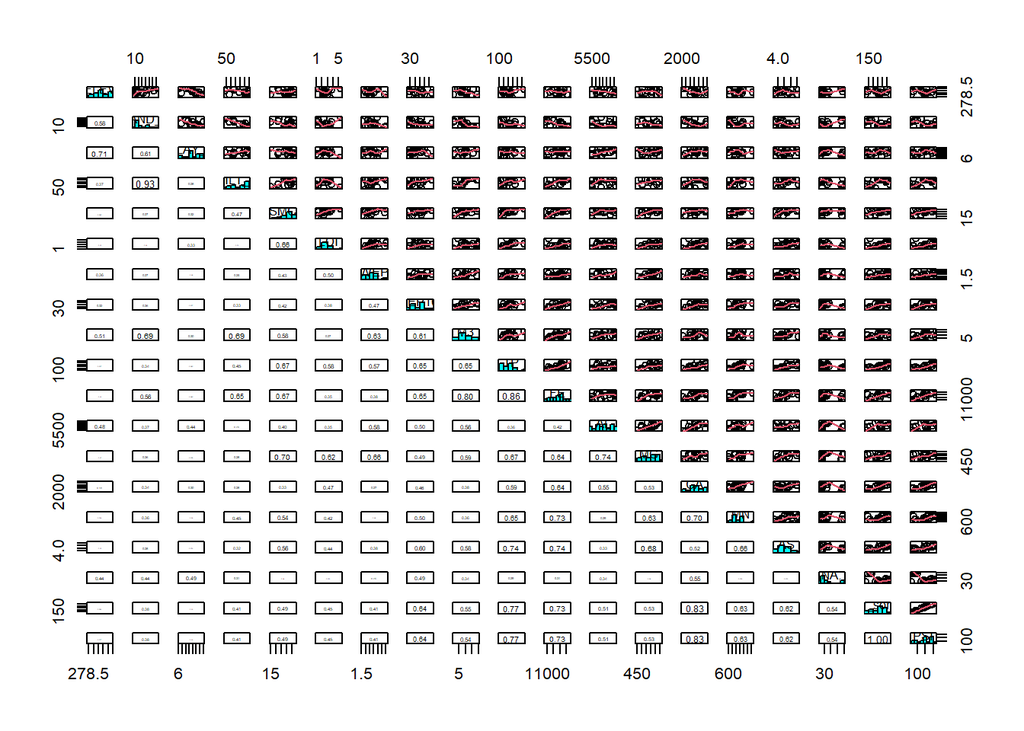

```r
library(s20x)
pairs20x(mydat1)
```

```r
cor(mydat1,y=NULL, use = "na.or.complete", method = c("spearman"))
```

```
##                ELEV       SAND_P      CLAY_P       SILT_P         SMC
## ELEV    1.000000000  0.645024729 -0.77593539 -0.423007588  0.09001404
## SAND_P  0.645024729  1.000000000 -0.59569332 -0.871763255 -0.16226260
## CLAY_P -0.775935387 -0.595693323  1.00000000  0.199384955 -0.29447875
## SILT_P -0.423007588 -0.871763255  0.19938496  1.000000000  0.30977405
## SMC     0.090014041 -0.162262598 -0.29447875  0.309774050  1.00000000
## LOI     0.125000383  0.006785936 -0.21982825  0.008636646  0.63223063
## WEP    -0.187500574 -0.240592273  0.08497563  0.164096268  0.52275879
## WEP100 -0.381018339 -0.304857002  0.09570559  0.351568962  0.34803922
## M3     -0.486127172 -0.726939469  0.22345001  0.719559373  0.43776832
## TP     -0.032059795 -0.335588555 -0.07484668  0.377383466  0.67401961
## FE     -0.154133632 -0.492934104  0.03680984  0.527353443  0.55882353
## AL     -0.443904861 -0.422866164  0.51656481  0.223725703  0.33333333
## MG     -0.110976215 -0.312232575  0.08711663  0.259374304  0.66176471
## CA     -0.177561944 -0.303627740  0.29570574  0.169638170  0.31127451
## MN      0.004932276 -0.308544788 -0.14478539  0.453597717  0.61519608
## AS     -0.125310170 -0.342154429 -0.03255528  0.358154457  0.56441760
## NA.     0.311966472  0.156116287 -0.29570574 -0.082360561  0.35294118
## P_sorb -0.014796829 -0.255686518 -0.01349694  0.282730284  0.34068627
## PSI    -0.014796829 -0.255686518 -0.01349694  0.282730284  0.34068627
##                 LOI         WEP      WEP100         M3          TP          FE
## ELEV    0.125000383 -0.18750057 -0.38101834 -0.4861272 -0.03205980 -0.15413363
## SAND_P  0.006785936 -0.24059227 -0.30485700 -0.7269395 -0.33558855 -0.49293410
## CLAY_P -0.219828253  0.08497563  0.09570559  0.2234500 -0.07484668  0.03680984
## SILT_P  0.008636646  0.16409627  0.35156896  0.7195594  0.37738347  0.52735344
## SMC     0.632230627  0.52275879  0.34803922  0.4377683  0.67401961  0.55882353
## LOI     1.000000000  0.63518519  0.50799854  0.3316939  0.77614305  0.58671986
## WEP     0.635185185  1.00000000  0.58179978  0.5975413  0.69988176  0.47970806
## WEP100  0.507998539  0.58179978  1.00000000  0.6707543  0.62990196  0.68627451
## M3      0.331693878  0.59754129  0.67075426  1.0000000  0.66707554  0.78724724
## TP      0.776143046  0.69988176  0.62990196  0.6670755  1.00000000  0.88480392
## FE      0.586719862  0.47970806  0.68627451  0.7872472  0.88480392  1.00000000
## AL      0.382536430  0.56211945  0.58823529  0.5076641  0.40686275  0.41421569
## MG      0.580569758  0.63961075  0.51470588  0.4647456  0.69117647  0.58333333
## CA      0.638380730  0.30873519  0.49264706  0.4206009  0.65931373  0.74019608
## MN      0.587949882  0.36285610  0.56862745  0.4647456  0.81862745  0.82598039
## AS      0.568967243  0.47290784  0.60490843  0.5500308  0.84908039  0.77914169
## NA.     0.046740786 -0.08118136 -0.23284314 -0.1630902  0.00000000 -0.08333333
## P_sorb  0.683891495  0.42804719  0.58088235  0.4831393  0.78431373  0.74509804
## PSI     0.683891495  0.42804719  0.58088235  0.4831393  0.78431373  0.74509804
```

[output cut: 25 more lines]

```
## SMC     0.34068627  0.34068627
## LOI     0.68389149  0.68389149
## WEP     0.42804719  0.42804719
## WEP100  0.58088235  0.58088235
## M3      0.48313927  0.48313927
## TP      0.78431373  0.78431373
## FE      0.74509804  0.74509804
## AL      0.36029412  0.36029412
## MG      0.42156863  0.42156863
## CA      0.78676471  0.78676471
## MN      0.66666667  0.66666667
## AS      0.60490843  0.60490843
## NA.    -0.28676471 -0.28676471
## P_sorb  1.00000000  1.00000000
## PSI     1.00000000  1.00000000
```

# Table Exporting

Soil Correlation Table: 0-10 cm bgs

```r
dat10tab<-cor(mydat10,y=NULL, use = "na.or.complete", method = c("spearman"))
print(dat10tab)
```

```
##                  Elev       SandPD        ClayPD       SiltPD          SMC
## Elev      1.000000000  0.454343263 -0.5015478705 -0.264600667  0.011844556
## SandPD    0.454343263  1.000000000 -0.4365105562 -0.828889116 -0.298667981
## ClayPD   -0.501547871 -0.436510556  1.0000000000 -0.022013424 -0.178695930
## SiltPD   -0.264600667 -0.828889116 -0.0220134238  1.000000000  0.483481395
## SMC       0.011844556 -0.298667981 -0.1786959298  0.483481395  1.000000000
## LOI       0.156285176  0.241332942 -0.4843711834 -0.088221126  0.453019931
## WEP_2024  0.068577784  0.007907092 -0.2889855823  0.027530872  0.049839680
## WEP_2025 -0.309650317 -0.019891277 -0.0386139193  0.004074075  0.092030695
## M3P      -0.361303456 -0.470944296  0.1240890857  0.454074800  0.252679563
## TP        0.076742850 -0.115963611 -0.2853450221  0.167159809  0.421286031
## Al_tot    0.063163183  0.073763509  0.1485242419 -0.264267324 -0.035718685
## As_tot   -0.255474611 -0.191365807  0.1228005107  0.163288329  0.455164724
## Fe_tot   -0.035035828 -0.153447835  0.0007413856  0.219154525  0.474442669
## Ca_tot    0.059462216  0.126804160 -0.1112078350 -0.194995759  0.051484173
## Mg_tot    0.043177957 -0.040952316 -0.0328680935 -0.005669915  0.361867228
## Na_tot    0.008143132 -0.065877200  0.0451065106  0.122534550  0.457748214
## Si_tot   -0.218850561 -0.002960408  0.1527254267  0.049550123 -0.007882744
## P_sorb    0.227979615 -0.073023407 -0.1668117525  0.010846793  0.044094101
## PSI       0.227979615 -0.073023407 -0.1668117525  0.010846793  0.044094101
##                  LOI     WEP_2024     WEP_2025        M3P          TP
## Elev      0.15628518  0.068577784 -0.309650317 -0.3613035  0.07674285
## SandPD    0.24133294  0.007907092 -0.019891277 -0.4709443 -0.11596361
## ClayPD   -0.48437118 -0.288985582 -0.038613919  0.1240891 -0.28534502
## SiltPD   -0.08822113  0.027530872  0.004074075  0.4540748  0.16715981
## SMC       0.45301993  0.049839680  0.092030695  0.2526796  0.42128603
## LOI       1.00000000  0.399827640  0.256067996  0.2496616  0.59236313
## WEP_2024  0.39982764  1.000000000  0.565480603  0.5368296  0.53034847
## WEP_2025  0.25606800  0.565480603  1.000000000  0.5653306  0.24549743
## M3P       0.24966155  0.536829612  0.565330564  1.0000000  0.45213749
## TP        0.59236313  0.530348472  0.245497432  0.4521375  1.00000000
## Al_tot    0.21486126  0.426298809  0.371037852  0.3503326  0.29264688
## As_tot    0.53384603  0.212518718  0.254329734  0.4379261  0.61660307
## Fe_tot    0.43318404  0.100160484  0.092512762  0.4794284  0.55622614
## Ca_tot    0.56571067  0.232145358  0.051313746  0.2384824  0.59662520
## Mg_tot    0.53233176  0.396941426  0.336746455  0.4503572  0.46212588
## Na_tot    0.19164326 -0.111152355  0.138662871  0.1342861 -0.03781720
## Si_tot   -0.48659030 -0.442827756 -0.005180715 -0.1544715 -0.61042001
## P_sorb    0.42181049  0.359442919 -0.065128985  0.2820892  0.65870182
## PSI       0.42181049  0.359442919 -0.065128985  0.2820892  0.65870182
```

[output cut: 25 more lines]

```
## SMC       0.457748214 -0.007882744  0.04409410  0.04409410
## LOI       0.191643257 -0.486590296  0.42181049  0.42181049
## WEP_2024 -0.111152355 -0.442827756  0.35944292  0.35944292
## WEP_2025  0.138662871 -0.005180715 -0.06512898 -0.06512898
## M3P       0.134286067 -0.154471549  0.28208919  0.28208919
## TP       -0.037817196 -0.610420007  0.65870182  0.65870182
## Al_tot    0.178593424 -0.288669951  0.39310345  0.39310345
## As_tot    0.246542412 -0.316167757  0.30900458  0.30900458
## Fe_tot    0.334031287 -0.166009852  0.36650246  0.36650246
## Ca_tot   -0.159871907 -0.616256158  0.70492611  0.70492611
## Mg_tot    0.599334898 -0.311822660  0.31231527  0.31231527
## Na_tot    1.000000000  0.235989656 -0.31703412 -0.31703412
## Si_tot    0.235989656  1.000000000 -0.76945813 -0.76945813
## P_sorb   -0.317034120 -0.769458128  1.00000000  1.00000000
## PSI      -0.317034120 -0.769458128  1.00000000  1.00000000
```

```r
write.csv(dat10tab,"LF_Soil_10_Cor030426.csv",row.names = TRUE)
```

Soil Correlation Table: 10-20 cm bgs

```r
dat20tab<-cor(mydat20,y=NULL, use = "na.or.complete", method = c("spearman"))
write.csv(dat20tab,"LF_Soil_20_Cor030426.csv",row.names=TRUE)
```

Soil Correlation Table: 20-30 cm bgs

```r
dat30tab<-cor(mydat30,y=NULL, use = "na.or.complete", method = c("spearman"))
write.csv(dat30tab,"LF_Soil_30_Cor030426.csv", row.names=TRUE)
```

Soil Correlation Table: All Depths

```r
datalltab<-cor(mydat1,y=NULL, use = "na.or.complete", method = c("spearman"))
write.csv(datalltab,"LF_Soil_All_Cor030426.csv", row.names=TRUE)
```